# Análise IMDB

Beatriz Milz e William Amorim

10 de fevereiro de 2021

## Melhor é ser lucrativo?

Como muitos fatores podem influenciar a receita de um filme, consequentemente o seu lucro, a variabilidade sobre essas variáveis pode ser muito grande. Assim, dentre os diretores que mais fizeram filmes de comédia, vamos olhar para aqueles que, em média, lucram mais.

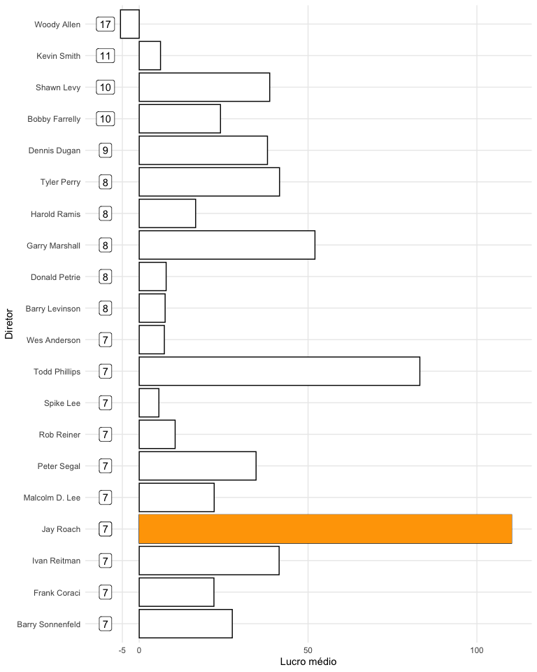

O diretor Jay Roach parece ser uma aposta mais segura, pois tem um lucro médio de 110 milhões de dólares com 7 filmes marcados como comédia na base.

Jay Roach é o diretor da série *Austin Powers* e *Entrando numa fria*.

| Filme | Orçamento | Receita | Lucro | Nota |
| --- | --- | --- | --- | --- |
| Austin Powers in Goldmember | $63.000.000 | $213.079.163 | $150.079.163 | 6.2 |
| Austin Powers: International Man of Mystery | $17.000.000 | $53.868.030 | $36.868.030 | 7.0 |
| Austin Powers: The Spy Who Shagged Me | $33.000.000 | $205.399.422 | $172.399.422 | 6.6 |
| Dinner for Schmucks | Sem informação | $72.980.108 | Sem informação | 5.9 |
| Meet the Fockers | $80.000.000 | $279.167.575 | $199.167.575 | 6.3 |
| Meet the Parents | $55.000.000 | $166.225.040 | $111.225.040 | 7.0 |
| The Campaign | $95.000.000 | $86.897.182 | -$8.102.818 | 6.2 |

## Melhor é ser bem avaliado?

Embora subjetiva, a nota IMDB é uma boa estimativa da opinião pública sobre um filme, pois é uma média de diversos olhares diferentes. Pelo menos um filme aclamado é um bom indício de que a direção sabe conduzir um filme de sucesso.

A tabela a seguir mostra que o filme marcado como comédia com maior nota na nossa base é Forrest Gump, dirigido por Robert Zemeckis.

| Filme | Direção | Nota IMDB |
| --- | --- | --- |
| Forrest Gump | Robert Zemeckis | 8.8 |
| A Beginner’s Guide to Snuff | Mitchell Altieri | 8.7 |
| Modern Times | Charles Chaplin | 8.6 |
| Back to the Future | Robert Zemeckis | 8.5 |
| Dr. Strangelove or: How I Learned to Stop Worrying and Love the Bomb | Stanley Kubrick | 8.5 |
| A Charlie Brown Christmas | Bill Melendez | 8.4 |
| Toy Story 3 | Lee Unkrich | 8.3 |
| Up | Pete Docter | 8.3 |
| Inside Out | Pete Docter | 8.3 |
| Toy Story | John Lasseter | 8.3 |
| The Sting | George Roy Hill | 8.3 |
| The Apartment | Billy Wilder | 8.3 |
| Some Like It Hot | Billy Wilder | 8.3 |
| Singin’ in the Rain | Stanley Donen | 8.3 |
| The Sound and the Shadow | Justin Paul Miller | 8.3 |

Vamos olhar mais atentamente os filmes dirigidos por Robert Zemeckis. Além de Forest Gump, ele é o diretor da consagrada trilogia *De Volta Para o Futuro*.

| Filme | Orçamento | Receita | Lucro | Nota |
| --- | --- | --- | --- | --- |
| Back to the Future | $19.000.000 | $210.609.762 | $191.609.762 | 8.5 |
| Back to the Future Part II | $40.000.000 | $118.500.000 | $78.500.000 | 7.8 |
| Back to the Future Part III | $40.000.000 | $87.666.629 | $47.666.629 | 7.4 |
| Death Becomes Her | $55.000.000 | $58.422.650 | $3.422.650 | 6.4 |
| Forrest Gump | $55.000.000 | $329.691.196 | $274.691.196 | 8.8 |

## Roach ou Zemeckis?

Comparando os dois diretores, percebemos que Robert Zemeckis se destaca nas duas categorias: lucro e nota IMDB. Embora tenha feito menos filmes (o que o deixou de fora na nossa análise do lucro), ele é já dirigiu grandes sucessos de bilheteria e crítica.

Pelos critérios analisados, indicamos Robert Zemeckis como o melhor diretor de comédia.

| Diretor | Nº filmes | Lucro | Nota |
| --- | --- | --- | --- |
| Jay Roach | 7 | $110.272.735 | 6.46 |
| Robert Zemeckis | 5 | $119.178.047 | 7.78 |